# scRNA-seq Analysis with Seurat

## A fictional table from ChatGPT

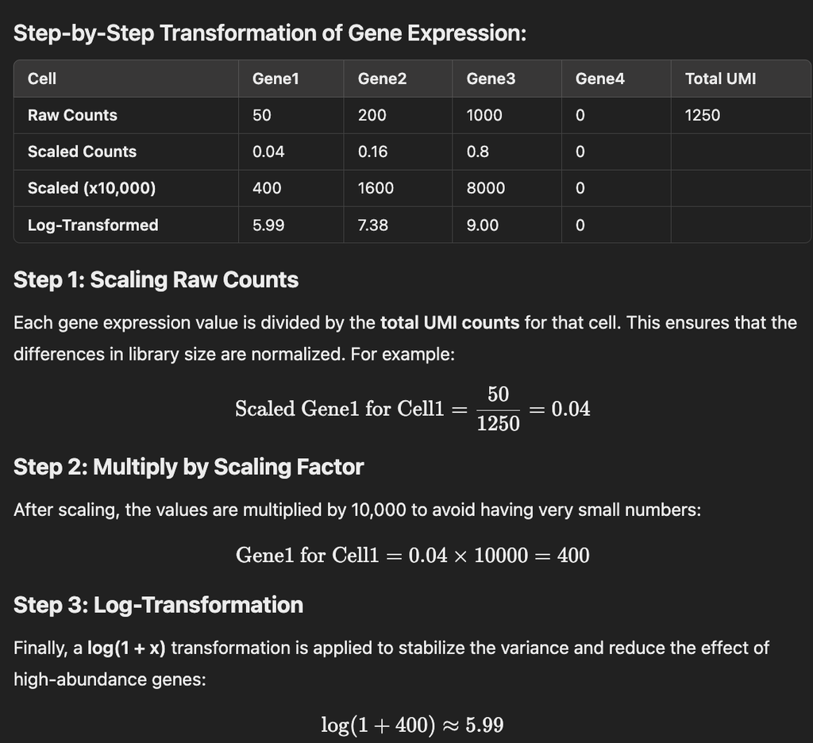

```r
# Perform normalization

pbmc_10x_v3 <- NormalizeData(pbmc_10x_v3, normalization.method = "LogNormalize", scale.factor = 10000)
#pbmc_10x_v3@assays$RNA@data
# View normalized data
head(pbmc_10x_v3@assays$RNA@data["MALAT1", 1:5])  # View the normalized data for the first 5 cells
```

```
## pbmc1_10x_v3_AAACCCACACTTGGGC pbmc1_10x_v3_AAACCCATCTTACACT
##                      5.889263                      6.278103
## pbmc1_10x_v3_AAAGAACAGCAGGCAT pbmc1_10x_v3_AAAGAACTCAAAGACA
##                      5.986086                      6.124765
## pbmc1_10x_v3_AAAGTGATCGTGACTA
##                      5.897881
```

```r
head(pbmc_10x_v3@assays$RNA@counts["MALAT1", 1:5])  # View the normalized data for the first 5 cells
```

```
## pbmc1_10x_v3_AAACCCACACTTGGGC pbmc1_10x_v3_AAACCCATCTTACACT
##                           249                           328
## pbmc1_10x_v3_AAAGAACAGCAGGCAT pbmc1_10x_v3_AAAGAACTCAAAGACA
##                           328                           264
## pbmc1_10x_v3_AAAGTGATCGTGACTA
##                           231
```

```r
pbmc_10x_v3
```

```
## An object of class Seurat
## 33694 features across 2311 samples within 1 assay
## Active assay: RNA (33694 features, 0 variable features)
##  2 layers present: counts, data
```

## Feature Selection in Seurat

### What is Feature Selection?

Feature selection is a crucial step in the analysis of single-cell RNA-seq data. It involves identifying the most variable genes across cells, which are more likely to carry biologically relevant information for downstream analyses such as clustering or trajectory inference.

In single-cell RNA-seq, many genes are either not expressed or have very low variation across cells. Including all genes can introduce noise and reduce the sensitivity of downstream analysis. Therefore, we focus on **highly variable genes** for dimensionality reduction and clustering.

### Highly Variable Genes (HVGs)

Seurat uses a method to calculate the **variance-to-mean ratio** (VMR) of each gene’s expression across cells. These values are then used to identify highly variable genes (HVGs).

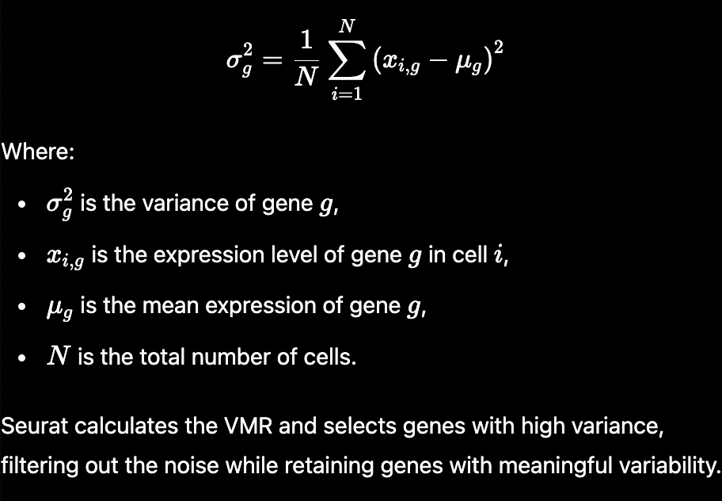

Alt Variance Formula

### Feature Selection in Seurat

Seurat offers a function, `FindVariableFeatures()`, that automatically identifies the highly variable features (genes) for downstream analysis.

```r
# Identify highly variable features
pbmc_10x_v3 <- FindVariableFeatures(pbmc_10x_v3, selection.method = "vst", nfeatures = 2000)

# View the top 10 variable features
top10 <- head(VariableFeatures(pbmc_10x_v3), 10)
top10
```

```
##  [1] "S100A9" "LYZ"    "S100A8" "IGKC"   "IGLC2"  "PPBP"   "NRGN"   "IGLC3"
##  [9] "GNLY"   "PF4"
```

## Scaling the Data in Seurat

### What is Scaling?

Scaling is an important step in single-cell RNA-seq analysis, where we standardize the expression values across genes and cells. This is crucial because genes may have different ranges of expression levels, and we want to make sure that highly expressed genes don’t dominate the downstream analysis.

In Seurat, scaling means subtracting the mean of each gene’s expression and dividing by the standard deviation (Z-score normalization). This standardizes the expression levels so that all genes have a mean of 0 and a variance of 1 across the dataset.

#### Important Note:

- **By default, Seurat only scales the highly variable genes** identified in the previous step (feature selection).
- If you’re planning to perform **regression-based corrections** (e.g., for mitochondrial genes or cell cycle effects), it’s best to apply them during this scaling step.

### Scaling the Data in Seurat

```r
all.genes <- rownames(pbmc_10x_v3)
pbmc_10x_v3 <- ScaleData(pbmc_10x_v3, features = all.genes)
head(pbmc_10x_v3@assays$RNA@scale.data[, 1:5])
```

```
##          pbmc1_10x_v3_AAACCCACACTTGGGC pbmc1_10x_v3_AAACCCATCTTACACT
## TSPAN6                     -0.14999978                   -0.14999978
## TNMD                        0.00000000                    0.00000000
## DPM1                        1.68786105                   -0.41457975
## SCYL3                      -0.19716199                   -0.19716199
## C1orf112                   -0.08179474                   -0.08179474
## FGR                        -0.42639369                   -0.42639369
##          pbmc1_10x_v3_AAAGAACAGCAGGCAT pbmc1_10x_v3_AAAGAACTCAAAGACA
## TSPAN6                     -0.14999978                   -0.14999978
## TNMD                        0.00000000                    0.00000000
## DPM1                        1.44899885                   -0.41457975
## SCYL3                       3.29098386                   -0.19716199
## C1orf112                   -0.08179474                   -0.08179474
## FGR                        -0.42639369                   -0.42639369
##          pbmc1_10x_v3_AAAGTGATCGTGACTA
## TSPAN6                     -0.14999978
## TNMD                        0.00000000
## DPM1                       -0.41457975
## SCYL3                      -0.19716199
## C1orf112                   -0.08179474
## FGR                        -0.42639369
```

### 2. Perform Linear Dimensional Reduction

## Linear Dimensional Reduction: PCA

### What is Linear Dimensional Reduction?

Linear dimensional reduction techniques, such as **Principal Component Analysis (PCA)**, are used to reduce the complexity of large single-cell RNA-seq datasets by projecting the data into fewer dimensions. PCA identifies the axes (principal components) that capture the most variance in the dataset, allowing us to simplify the dataset while retaining its most informative aspects.

### Why PCA?

- PCA reduces noise by focusing on the most informative components, which speeds up the clustering process and other downstream analyses.
- We can identify the **principal components** (PCs) that explain the most variance, helping to reduce dimensionality before clustering.

### Important Note:

- PCA assumes that the data is linearly separable and works best when the signal in the data is structured. However, for capturing non-linear patterns, Seurat later uses techniques like UMAP or t-SNE.

## I strongly recommend you guys to watch the following video; StatQuest: Principal Component Analysis (PCA), Step-by-Step

https://www.youtube.com/watch?v=FgakZw6K1QQ

### Running PCA in Seurat

```r
# Perform PCA on the scaled data
pbmc_10x_v3 <- RunPCA(pbmc_10x_v3, features = VariableFeatures(object = pbmc_10x_v3))
```

```
## PC_ 1
## Positive:  RPSA, IL32, RPL10, RPL37, RPS18, RPS19, RPS12, RPS6, TRAC, RPS8
##     TRBC2, EEF1B2, CCL5, RPL32, RPLP0, RORA, LDHB, KLF2, CST7, SPOCK2
##     CD69, CTSW, ITM2A, CD247, GZMM, ARL4C, TRBC1, IL7R, SYNE2, NKG7
## Negative:  LYZ, FCN1, S100A9, CST3, VCAN, CLEC7A, S100A8, CPVL, SERPINA1, CSTA
##     CD14, MPEG1, NCF2, NAMPT, CYBB, DUSP6, MAFB, MS4A6A, SPI1, TNFAIP2
##     FGL2, TGFBI, AIF1, CSF3R, FCER1G, SLC11A1, S100A12, CFD, SLC7A7, CLEC12A
## PC_ 2
## Positive:  SDPR, TUBB1, PF4, GNG11, PPBP, HIST1H2AC, RGS18, NRGN, HIST1H3H, MAP3K7CL
##     TSC22D1, ACRBP, SPARC, PRKAR2B, CA2, NXF3, TMSB4X, GMPR, TMEM40, C2orf88
##     CMTM5, CLU, HIST1H2BJ, C6orf25, SMOX, CCL5, TREML1, CTTN, AP003068.23, PGRMC1
## Negative:  RPL13, RPL34, RPLP1, EEF1A1, RPL32, RPS8, RPL37, RPS12, RPS6, RPS18
##     RPL10, RPS19, CD79A, JUND, HLA-DQA1, RPSA, TPT1, EEF1B2, MS4A1, RPLP0
##     HLA-DQB1, LINC00926, CD74, IGHM, HLA-DRA, IGHD, CD37, TNFRSF13C, BANK1, CD83
## PC_ 3
## Positive:  CD79A, HLA-DQA1, BANK1, TSPAN33, TUBB1, MS4A1, SDPR, PF4, GNG11, PPBP
##     HIST1H2AC, LINC00926, PDLIM1, IGHM, RGS18, HIST1H3H, MAP3K7CL, IGHD, HLA-DQB1, ACRBP
##     CA2, NRGN, TNFRSF13C, IGKC, PRKAR2B, SPARC, TSC22D1, NXF3, C2orf88, TMEM40
## Negative:  S100A4, IL32, ANXA1, NKG7, ITGB2, S100A6, CST7, HCST, SRGN, CTSW
##     ARL4C, S100A10, GZMA, GZMH, PRF1, GZMM, CD247, EFHD2, MYO1F, ID2
##     FGFBP2, GZMB, NEAT1, PFN1, KLRD1, CD7, GNLY, RORA, LGALS1, LCP1
## PC_ 4
## Positive:  IL7R, LTB, LEPROTL1, RCAN3, SARAF, MAL, TCF7, LEF1, LDHB, NOSIP
##     ZFP36L2, VIM, CAMK4, TPT1, JUNB, TMEM123, TRABD2A, PIK3IP1, SATB1, PABPC1
##     RGS10, NELL2, TOB1, PAG1, BCL11B, AQP3, TNFRSF25, TRAT1, CD40LG, DNAJB1
## Negative:  NKG7, GZMB, GZMH, FGFBP2, CST7, PRF1, EFHD2, GNLY, KLRD1, GZMA
##     HLA-DPA1, HLA-DPB1, CTSW, CCL5, HLA-DRB1, ZEB2, SPON2, ADGRG1, FCGR3A, CCL4
##     PRSS23, CD74, KLRF1, CLIC3, CEP78, HOPX, C12orf75, S1PR5, ITGB2, TTC38
## PC_ 5
## Positive:  S100A12, CD14, MGST1, VCAN, S100A8, EGR1, RP11-1143G9.4, PLBD1, MS4A6A, CSF3R
##     QPCT, CLEC4E, CD93, THBS1, RBP7, S100A9, CXCL8, RNASE6, IER3, MARC1
##     FOSB, CD163, CDA, LUCAT1, CD36, CTB-61M7.2, FPR1, SGK1, BST1, ALDH1A1
## Negative:  CDKN1C, CSF1R, HES4, MS4A7, ZNF703, SIGLEC10, FCGR3A, CTSL, RRAS, TCF7L2
##     LRRC25, CTD-2006K23.1, FAM110A, CKB, IFITM3, CDH23, IFI30, LILRB2, LST1, HMOX1
##     MTSS1, PECAM1, PAPSS2, PILRA, PLXNB2, TAGLN, MYOF, AIF1, CFD, PLD4
```

```r
# Visualize the first two principal components
print(pbmc_10x_v3[["pca"]], dims = 1:2, nfeatures = 5)
```

```
## PC_ 1
## Positive:  RPSA, IL32, RPL10, RPL37, RPS18
## Negative:  LYZ, FCN1, S100A9, CST3, VCAN
## PC_ 2
## Positive:  SDPR, TUBB1, PF4, GNG11, PPBP
## Negative:  RPL13, RPL34, RPLP1, EEF1A1, RPL32
```

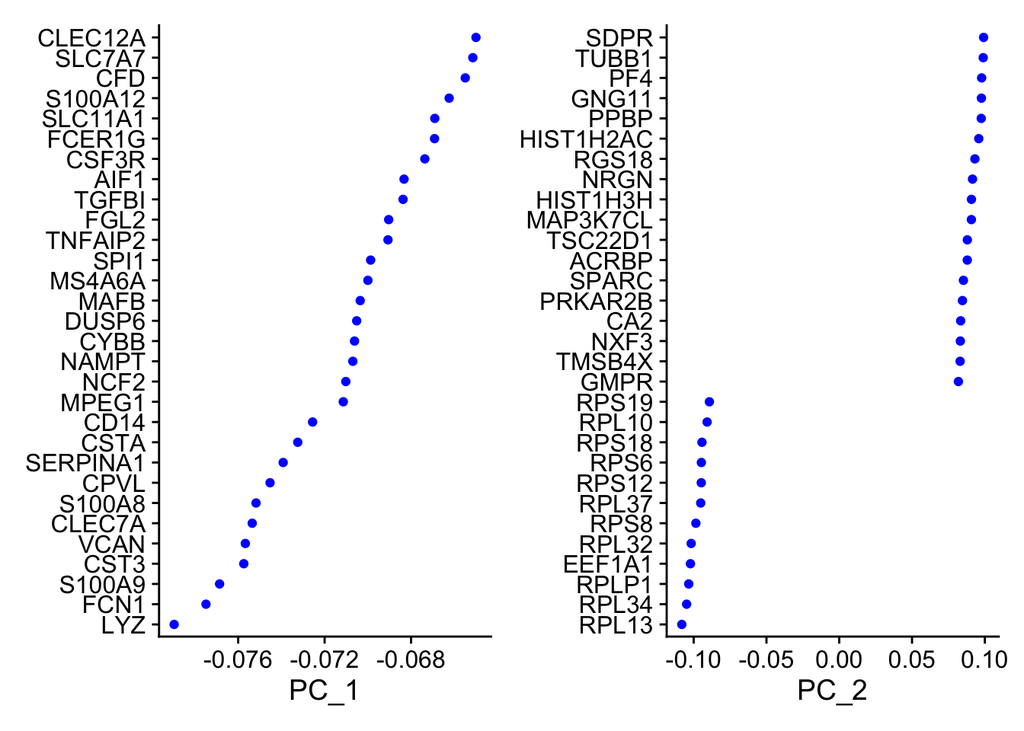

```r
# Perform PCA on the scaled data
VizDimLoadings(pbmc_10x_v3, dims = 1:2, reduction = "pca")
```

```r
# Visualize the first two principal components
print(pbmc_10x_v3[["pca"]], dims = 1:2, nfeatures = 5)
```

```
## PC_ 1
## Positive:  RPSA, IL32, RPL10, RPL37, RPS18
## Negative:  LYZ, FCN1, S100A9, CST3, VCAN
## PC_ 2
## Positive:  SDPR, TUBB1, PF4, GNG11, PPBP
## Negative:  RPL13, RPL34, RPLP1, EEF1A1, RPL32
```

## Determine the ‘dimensionality’ of the dataset

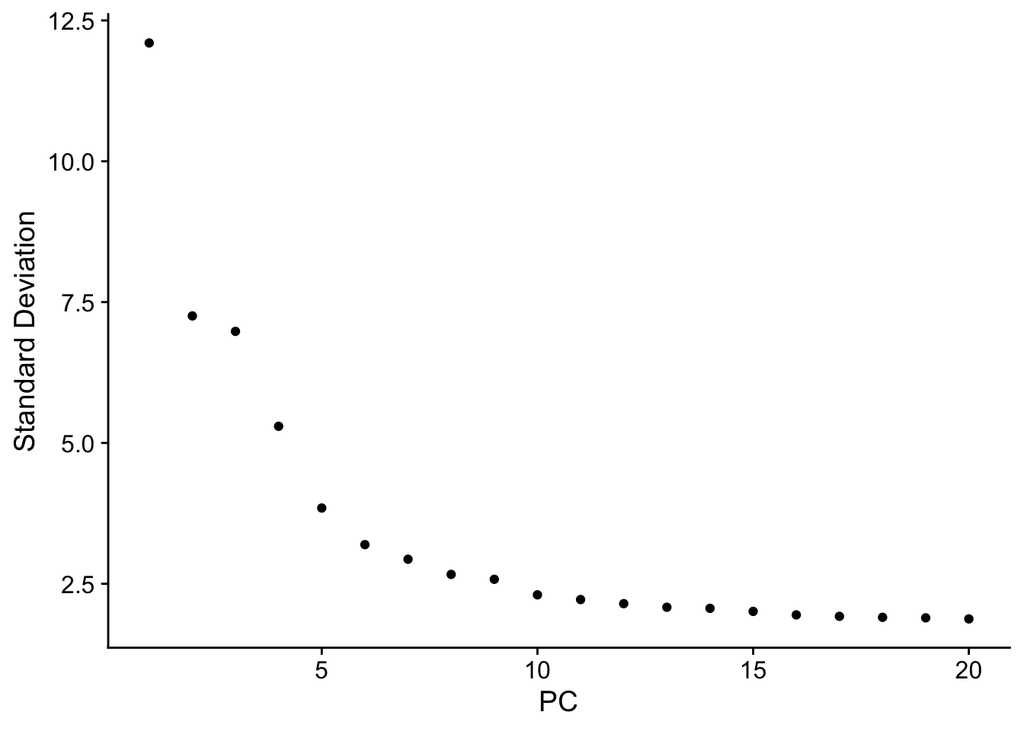

```r
ElbowPlot(pbmc_10x_v3)
```

## Clustering the Cells

### What is Clustering?

Clustering is the process of grouping cells with similar gene expression profiles. In single-cell RNA-seq data, clustering helps to identify distinct cell types or states. Seurat uses a graph-based clustering method, which is particularly effective for high-dimensional scRNA-seq data.

### Graph-Based Clustering in Seurat

Seurat’s clustering algorithm follows these steps: 1. **Find Neighbors**: Constructs a nearest neighbor graph of the cells based on their PCA scores. 2. **Find Clusters**: Partitions the graph into communities (clusters) using the Louvain algorithm.

### Clustering Cells in Seurat

```r
# Construct the KNN graph
pbmc_10x_v3 <- FindNeighbors(pbmc_10x_v3, dims = 1:10)
# Perform clustering
pbmc_10x_v3 <- FindClusters(pbmc_10x_v3, resolution = 0.5)
```

```
## Modularity Optimizer version 1.3.0 by Ludo Waltman and Nees Jan van Eck
##
## Number of nodes: 2311
## Number of edges: 76465
##
## Running Louvain algorithm...
## Maximum modularity in 10 random starts: 0.8997
## Number of communities: 11
## Elapsed time: 0 seconds
```

## Non-Linear Dimensional Reduction: UMAP and t-SNE

#### UMAP (Uniform Manifold Approximation and Projection)

#### UMAP is a non-linear dimensional reduction technique that preserves local and global structures.

##### Perform UMAP using the first 30 principal components

```r
pbmc_10x_v3 <- RunUMAP(pbmc_10x_v3, dims = 1:30)
```

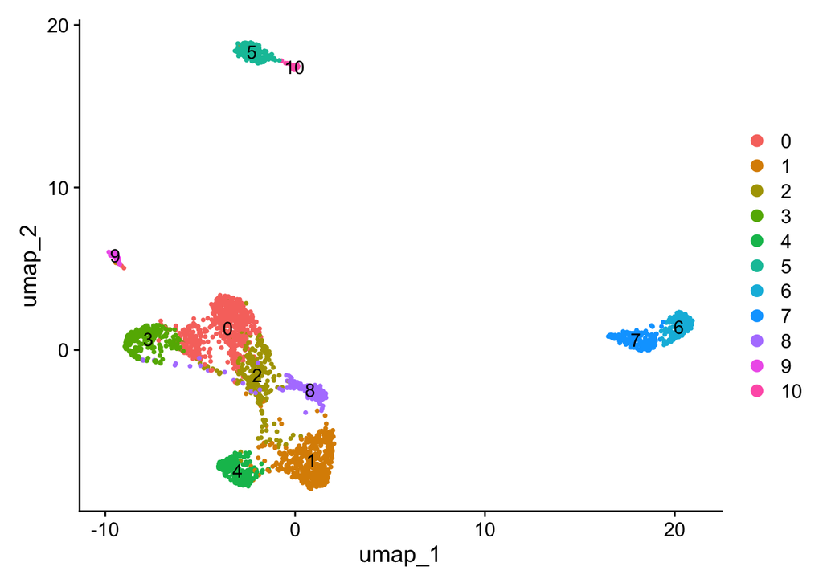

```r
##### Visualize the clusters in UMAP space

DimPlot(pbmc_10x_v3, reduction = "umap", label = TRUE)
```

### —- Detailed Explanation for UMAP —-

##### UMAP is a faster method than t-SNE and is often preferred for visualizing large single-cell RNA-seq datasets.

##### UMAP preserves both local and global structures in the data, allowing for better separation of clusters.

##### It’s commonly used in scRNA-seq to create a 2D or 3D map of cells, based on their gene expression profiles.

# ————————————————————————

#### t-SNE (t-distributed Stochastic Neighbor Embedding)

##### t-SNE is a non-linear dimensional reduction technique that is commonly used in single-cell RNA-seq visualization.

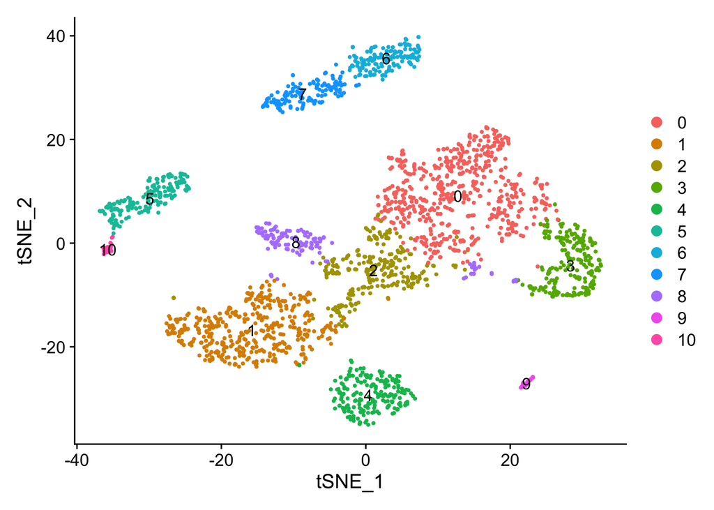

```r
##### Perform t-SNE using the first 10 principal components

pbmc_10x_v3 <- RunTSNE(pbmc_10x_v3, dims = 1:10)

#### Visualize the clusters in t-SNE space

DimPlot(pbmc_10x_v3, reduction = "tsne", label = TRUE)
```

#### —- Detailed Explanation for t-SNE —-

##### t-SNE is slower than UMAP and focuses more on preserving local structures (neighborhoods).

##### It can sometimes distort global relationships (i.e., distances between clusters) but is still widely used in scRNA-seq.

#### t-SNE is known to give slightly different results each time due to its stochastic nature, unlike UMAP which is more consistent.

# ————————————————————————

### Additional Notes:

##### - Both UMAP and t-SNE work on the top principal components (PCs) from PCA. Usually, the first 10-30 PCs are used,

##### depending on the dataset.

##### This is set using the `dims` argument (as shown above, dims = 1:10).

##### - UMAP is often preferred for larger datasets due to its speed and ability to preserve both local and global structure.

##### - If you observe clusters that are not well separated, try adjusting the number of PCs or using a different resolution

##### during the clustering process.

## Visualizing Data

#### 1. **UMAP Plot**

We can use UMAP for dimensional reduction and visualize the cells in 2D space.

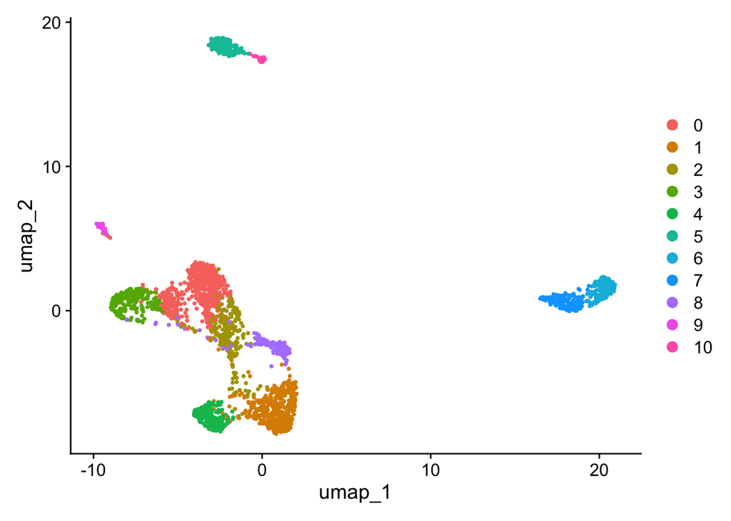

```r
DimPlot(pbmc_10x_v3, reduction = "umap")
```

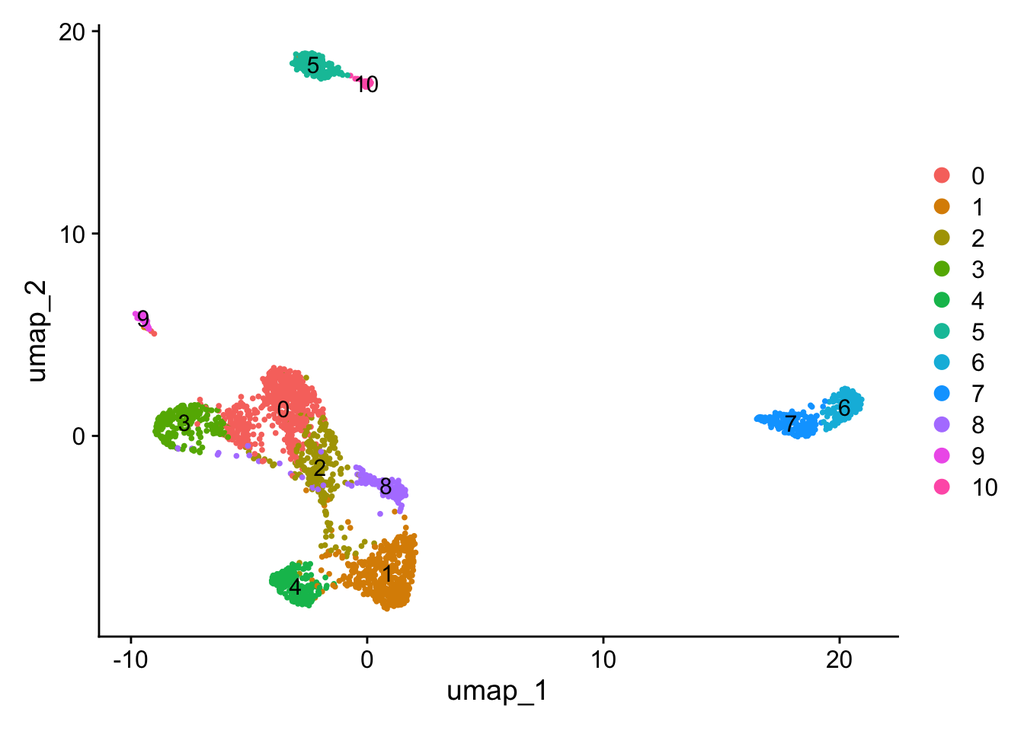

```r
DimPlot(pbmc_10x_v3, reduction = "umap", label = TRUE)
```

### Finding Cluster Biomarkers (Differentially Expressed Features)

##### Explanation:

##### Finding differentially expressed features (markers) between clusters helps identify genes

##### that define distinct cell types or states within the dataset. Seurat’s FindMarkers() function

##### identifies genes that are significantly upregulated in one cluster compared to all others.

##### Find markers for cluster 1 compared to all other clusters

```r
cluster1_markers <- FindMarkers(pbmc_10x_v3, ident.1 = 1, min.pct = 0.25)

# Explanation:
# - `ident.1 = 1`: Specifies that we are finding markers for cluster 1.
# - `min.pct = 0.25`: The minimum fraction of cells in the cluster that must express the gene
#   for it to be considered a marker (here, 25% of cells).
# - This returns a data frame with markers, their fold changes, and statistical significance.

# View the top 5 markers for cluster 1
head(cluster1_markers, n = 5)
```

```
##                 p_val avg_log2FC pct.1 pct.2     p_val_adj
## IL7R    1.437281e-156  2.1598498 0.949 0.305 4.842774e-152
## LTB     2.765103e-142  2.0884491 0.957 0.371 9.316738e-138
## TPT1    4.342265e-106  0.6119134 1.000 0.993 1.463083e-101
## ZFP36L2 6.778540e-100  1.3329570 0.995 0.844  2.283961e-95
## LDHB     2.593815e-92  1.3527786 0.957 0.646  8.739599e-88
```

```r
# Explanation:
# The head() function shows the top 5 differentially expressed genes (markers) for cluster 1.
# Each row represents a gene, and the columns include p-values, fold changes, and other statistics.
```

# ————————————————————————

### Finding Markers for All Clusters

##### Explanation:

##### You can identify markers for all clusters in the dataset using FindAllMarkers().

##### This function compares each cluster to all others and finds upregulated genes (markers).

```r
library(dplyr)
all_markers <- FindAllMarkers(pbmc_10x_v3, only.pos = TRUE, min.pct = 0.25, logfc.threshold = 0.25)
pbmc.markers <- FindAllMarkers(pbmc_10x_v3, only.pos = TRUE)
pbmc.markers %>%
    group_by(cluster) %>%
    dplyr::filter(avg_log2FC > 1)
```

```
## # A tibble: 10,153 × 7
## # Groups:   cluster [11]
##        p_val avg_log2FC pct.1 pct.2 p_val_adj cluster gene
##        <dbl>      <dbl> <dbl> <dbl>     <dbl> <fct>   <chr>
##  1 1.34e-262       2.80 0.979 0.207 4.51e-258 0       GZMH
##  2 4.33e-205       2.42 0.892 0.189 1.46e-200 0       FGFBP2
##  3 1.82e-198       2.02 1     0.427 6.12e-194 0       NKG7
##  4 1.26e-184       1.85 1     0.447 4.25e-180 0       CCL5
##  5 2.39e-163       1.81 0.833 0.176 8.07e-159 0       GZMB
##  6 3.79e-159       2.41 0.816 0.246 1.28e-154 0       CD8A
##  7 2.11e-158       1.68 0.986 0.361 7.11e-154 0       CST7
##  8 1.98e-129       1.69 0.851 0.359 6.68e-125 0       C12orf75
##  9 3.77e-125       2.26 0.714 0.19  1.27e-120 0       CD8B
## 10 3.72e-122       1.25 0.833 0.256 1.25e-117 0       PRF1
## # ℹ 10,143 more rows
```

```r
# Explanation:
# - `only.pos = TRUE`: Returns only genes that are positively upregulated in each cluster.
# - `min.pct = 0.25`: Filters genes expressed in at least 25% of the cells.
# - `logfc.threshold = 0.25`: Filters markers with a log-fold change greater than 0.25.

# View the top markers for each cluster
head(all_markers)
```

```
##                p_val avg_log2FC pct.1 pct.2     p_val_adj cluster   gene
## GZMH   1.337626e-262  2.8015416 0.979 0.207 4.506998e-258       0   GZMH
## FGFBP2 4.329479e-205  2.4174123 0.892 0.189 1.458774e-200       0 FGFBP2
## NKG7   1.815093e-198  2.0246653 1.000 0.427 6.115773e-194       0   NKG7
## CCL5   1.260112e-184  1.8531616 1.000 0.447 4.245821e-180       0   CCL5
## GZMB   2.393621e-163  1.8110780 0.833 0.176 8.065066e-159       0   GZMB
## B2M    2.248714e-160  0.6815216 1.000 1.000 7.576816e-156       0    B2M
```

```r
# Explanation:
# The head() function shows the top markers for each cluster. Each row represents a gene, and
# the data frame includes information such as p-values, fold changes, and the cluster it was found in.
```

# ————————————————————————

### Visualizing Markers for Specific Clusters

##### Explanation:

##### Once markers are identified, you can visualize their expression across clusters using

##### Seurat’s plotting functions, such as VlnPlot() for violin plots and FeaturePlot() for spatial gene plots.

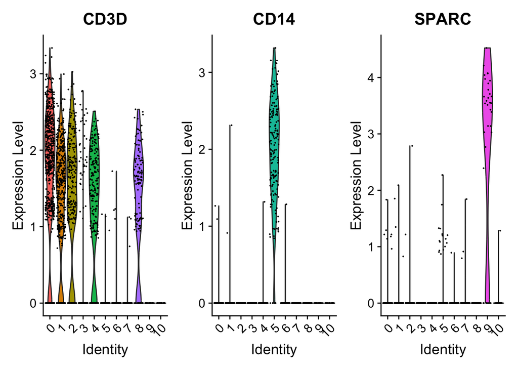

```r
# Example: Visualize the expression of CD3D and CD14 (common immune cell markers)
# Using Violin Plot (VlnPlot)
VlnPlot(pbmc_10x_v3, features = c("CD3D", "CD14","SPARC"), pt.size = 0.1)
```

```r
# Explanation:
# - `features = c("CD3D", "CD14")`: Specifies the genes to visualize (e.g., CD3D, a T-cell marker, and CD14, a monocyte marker).
# - `pt.size = 0.1`: Controls the size of individual points on the plot.

# Example: Visualize gene expression spatially across the UMAP plot using FeaturePlot
#raw_counts_v2FeaturePlot(pbmc_10x_v3, features = c("CD3D", "CD14"))

# Explanation:
# - `FeaturePlot()` shows where specific genes are expressed across the UMAP (or t-SNE) plot.
#   In this example, we visualize the expression of CD3D and CD14 across the clusters.
```

```r
pbmc.markers %>%
    group_by(cluster) %>%
    dplyr::filter(avg_log2FC > 1) %>%
    slice_head(n = 5) %>%
    ungroup() -> top10
```

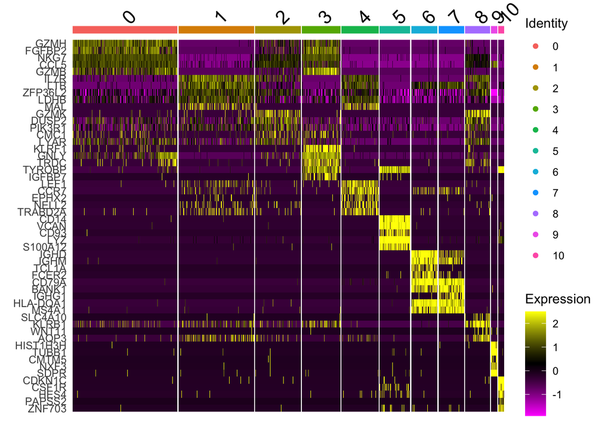

```r
DoHeatmap(pbmc_10x_v3, features = top10$gene)
```